# 문서화

# 1개일경우

## 2개 일경우

### 3개일경우

- `*`,`+`을 사용하면 아래와 같은 결과가 나옴
- 별을 사용하여 주석달기
  - 플러스를 사용하여 주석달기

##### Markdown Text

- 마크다운 문법을 이용해 텍스트를 입력
- https://www.markdownguide.org/basic-syntax/
- 일반적인 마크다운과 사용법이 동일하며, Latex를 이용해 수식도 입력 가능

##### 수식 출력

- 수식의 경우 인라인에 삽입할 경우 `$수식$`, 새로운 줄에 삽입할 경우 `$$수식$$`을 입력하여 출력 가능

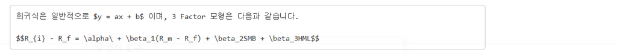

- 위 내용을 출력하면 다음과 같음

$$R_{i} - R_f = \alpha\ + \beta_1(R_m - R_f) + \beta_2SMB + \beta_3HML$$

회귀식은 일반적으로 y=ax+b이며, 3 Factor 모형은 다음과 같습니다. Ri−Rf=α +β1(Rm−Rf)+β2SMB+β3HML

- 수식이 길어질 경우 latex를 이용하면 깔끔하게 표현할 수 있음

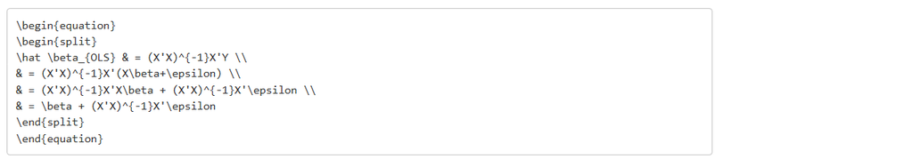

- latex의 경우 `$$`와 다르게 바로 렌더링 되지 않으므로 먼저 `$$`를 통해 수식이 맞게 표현되었는지 확인
- &=은 정렬을 할 위치를 나타내며, `\\`는 줄바꿈을 의미
- 위 내용을 출력하면 다음과 같음

$$\begin{equation}
\begin{split}
\hat \beta_{OLS} & = (X'X)^{-1}X'Y \\
& = (X'X)^{-1}X'(X\beta+\epsilon) \\
& = (X'X)^{-1}X'X\beta + (X'X)^{-1}X'\epsilon \\
& = \beta + (X'X)^{-1}X'\epsilon
\end{split}
\end{equation}$$

##### 행렬 출력

- 행렬 역시 latex를 이용해 출력 가능

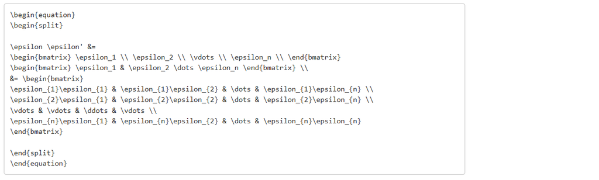

$$\begin{equation}
\begin{split}
\epsilon \epsilon' &=
\begin{bmatrix} \epsilon_1 \\ \epsilon_2 \\ \vdots \\ \epsilon_n \\ \end{bmatrix}
\begin{bmatrix} \epsilon_1 & \epsilon_2 \dots \epsilon_n \end{bmatrix} \\
&= \begin{bmatrix}
\epsilon_{1}\epsilon_{1} & \epsilon_{1}\epsilon_{2} & \dots & \epsilon_{1}\epsilon_{n} \\
\epsilon_{2}\epsilon_{1} & \epsilon_{2}\epsilon_{2} & \dots & \epsilon_{2}\epsilon_{n} \\
\vdots & \vdots & \ddots & \vdots \\
\epsilon_{n}\epsilon_{1} & \epsilon_{n}\epsilon_{2} & \dots & \epsilon_{n}\epsilon_{n}
\end{bmatrix}
\end{split}
\end{equation}$$

##### HTML, CSS 적용

- HTML과 CSS를 입력할 경우 그대로 적용되어 출력됨
- markdown으로 표현에 한계가 있는 부분은 css를 이용해 직접 표현

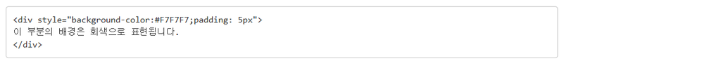

- 위 내용을 출력하면 다음과 같음

이 부분의 배경은 회색으로 표현됩니다.

#### 7.2.2 표만들기

- 마크다운 문법으로 표를 출력하기에는 한계가 있으므로, data.frame이나 tibble 형태의 표를 만든 후 kable() 함수로 변환하여 출력하는 것이 훨씬 효율적
- 3 Factor의 2018~2019년 데이터를 이용해 다음과 같은 테이블을 생성 후 출력

```r
library(dplyr)
library(stringr)
library(tidyr)
setwd("C:/Users/haley/Desktop/haley/task/Rbasic/statistic_lecture/rmd")
ff_mod = read.csv("ff_mod.csv")
ff_select = ff_mod %>%
  filter(str_sub(Date, 1, 4) %in% c(2018, 2019))

print(ff_select)
```

```
##       Date  Mkt.RF     SMB     HML     RF
## 1  2018-01  0.0558 -0.0303 -0.0137 0.0011
## 2  2018-02 -0.0365  0.0026 -0.0119 0.0011
## 3  2018-03 -0.0235  0.0395 -0.0012 0.0012
## 4  2018-04  0.0029  0.0112  0.0054 0.0014
## 5  2018-05  0.0265  0.0523 -0.0316 0.0014
## 6  2018-06  0.0048  0.0118 -0.0238 0.0014
## 7  2018-07  0.0319 -0.0217  0.0043 0.0016
## 8  2018-08  0.0344  0.0115 -0.0408 0.0016
## 9  2018-09  0.0006 -0.0237 -0.0130 0.0015
## 10 2018-10 -0.0768 -0.0476  0.0344 0.0019
## 11 2018-11  0.0169 -0.0079  0.0025 0.0018
## 12 2018-12 -0.0955 -0.0263 -0.0147 0.0019
## 13 2019-01  0.0841  0.0301 -0.0062 0.0021
## 14 2019-02  0.0340  0.0206 -0.0284 0.0018
## 15 2019-03  0.0110 -0.0313 -0.0407 0.0019
## 16 2019-04  0.0396 -0.0168  0.0193 0.0021
## 17 2019-05 -0.0694 -0.0120 -0.0239 0.0021
## 18 2019-06  0.0693  0.0034 -0.0108 0.0018
## 19 2019-07  0.0119 -0.0207  0.0014 0.0019
## 20 2019-08 -0.0258 -0.0241 -0.0499 0.0016
## 21 2019-09  0.0144 -0.0090  0.0671 0.0018
## 22 2019-10  0.0206  0.0025 -0.0207 0.0015
## 23 2019-11  0.0387  0.0087 -0.0186 0.0012
## 24 2019-12  0.0277  0.0068  0.0183 0.0014
```

```r
ff_1819 = ff_select %>%
  separate(Date, c('Year', 'Month'), sep = '-')

print(ff_1819)
```

```
##    Year Month  Mkt.RF     SMB     HML     RF
## 1  2018    01  0.0558 -0.0303 -0.0137 0.0011
## 2  2018    02 -0.0365  0.0026 -0.0119 0.0011
## 3  2018    03 -0.0235  0.0395 -0.0012 0.0012
## 4  2018    04  0.0029  0.0112  0.0054 0.0014
## 5  2018    05  0.0265  0.0523 -0.0316 0.0014
## 6  2018    06  0.0048  0.0118 -0.0238 0.0014
## 7  2018    07  0.0319 -0.0217  0.0043 0.0016
## 8  2018    08  0.0344  0.0115 -0.0408 0.0016
## 9  2018    09  0.0006 -0.0237 -0.0130 0.0015
## 10 2018    10 -0.0768 -0.0476  0.0344 0.0019
## 11 2018    11  0.0169 -0.0079  0.0025 0.0018
## 12 2018    12 -0.0955 -0.0263 -0.0147 0.0019
## 13 2019    01  0.0841  0.0301 -0.0062 0.0021
## 14 2019    02  0.0340  0.0206 -0.0284 0.0018
## 15 2019    03  0.0110 -0.0313 -0.0407 0.0019
## 16 2019    04  0.0396 -0.0168  0.0193 0.0021
## 17 2019    05 -0.0694 -0.0120 -0.0239 0.0021
## 18 2019    06  0.0693  0.0034 -0.0108 0.0018
## 19 2019    07  0.0119 -0.0207  0.0014 0.0019
## 20 2019    08 -0.0258 -0.0241 -0.0499 0.0016
## 21 2019    09  0.0144 -0.0090  0.0671 0.0018
## 22 2019    10  0.0206  0.0025 -0.0207 0.0015
## 23 2019    11  0.0387  0.0087 -0.0186 0.0012
## 24 2019    12  0.0277  0.0068  0.0183 0.0014
```

- knitr 패키지의 kable() 함수를 이용해 테이블 형태로 출력 가능

```r
library(knitr)

ff_1819 %>%
  kable()
```

| Year | Month | Mkt.RF | SMB | HML | RF |
| --- | --- | --- | --- | --- | --- |
| 2018 | 01 | 0.0558 | -0.0303 | -0.0137 | 0.0011 |
| 2018 | 02 | -0.0365 | 0.0026 | -0.0119 | 0.0011 |
| 2018 | 03 | -0.0235 | 0.0395 | -0.0012 | 0.0012 |
| 2018 | 04 | 0.0029 | 0.0112 | 0.0054 | 0.0014 |
| 2018 | 05 | 0.0265 | 0.0523 | -0.0316 | 0.0014 |
| 2018 | 06 | 0.0048 | 0.0118 | -0.0238 | 0.0014 |
| 2018 | 07 | 0.0319 | -0.0217 | 0.0043 | 0.0016 |
| 2018 | 08 | 0.0344 | 0.0115 | -0.0408 | 0.0016 |
| 2018 | 09 | 0.0006 | -0.0237 | -0.0130 | 0.0015 |
| 2018 | 10 | -0.0768 | -0.0476 | 0.0344 | 0.0019 |
| 2018 | 11 | 0.0169 | -0.0079 | 0.0025 | 0.0018 |
| 2018 | 12 | -0.0955 | -0.0263 | -0.0147 | 0.0019 |
| 2019 | 01 | 0.0841 | 0.0301 | -0.0062 | 0.0021 |
| 2019 | 02 | 0.0340 | 0.0206 | -0.0284 | 0.0018 |
| 2019 | 03 | 0.0110 | -0.0313 | -0.0407 | 0.0019 |
| 2019 | 04 | 0.0396 | -0.0168 | 0.0193 | 0.0021 |
| 2019 | 05 | -0.0694 | -0.0120 | -0.0239 | 0.0021 |
| 2019 | 06 | 0.0693 | 0.0034 | -0.0108 | 0.0018 |
| 2019 | 07 | 0.0119 | -0.0207 | 0.0014 | 0.0019 |
| 2019 | 08 | -0.0258 | -0.0241 | -0.0499 | 0.0016 |
| 2019 | 09 | 0.0144 | -0.0090 | 0.0671 | 0.0018 |
| 2019 | 10 | 0.0206 | 0.0025 | -0.0207 | 0.0015 |
| 2019 | 11 | 0.0387 | 0.0087 | -0.0186 | 0.0012 |
| 2019 | 12 | 0.0277 | 0.0068 | 0.0183 | 0.0014 |

- kableExtra 패키지의 kable_styling() 함수를 추가하여 깔끔한 html 형태로 출력

```r
library(kableExtra)
ff_1819 %>%
  kable() %>%
  kable_styling(c("striped", "bordered"))
```

| Year | Month | Mkt.RF | SMB | HML | RF |
| --- | --- | --- | --- | --- | --- |
| 2018 | 01 | 0.0558 | -0.0303 | -0.0137 | 0.0011 |
| 2018 | 02 | -0.0365 | 0.0026 | -0.0119 | 0.0011 |
| 2018 | 03 | -0.0235 | 0.0395 | -0.0012 | 0.0012 |
| 2018 | 04 | 0.0029 | 0.0112 | 0.0054 | 0.0014 |
| 2018 | 05 | 0.0265 | 0.0523 | -0.0316 | 0.0014 |
| 2018 | 06 | 0.0048 | 0.0118 | -0.0238 | 0.0014 |
| 2018 | 07 | 0.0319 | -0.0217 | 0.0043 | 0.0016 |
| 2018 | 08 | 0.0344 | 0.0115 | -0.0408 | 0.0016 |
| 2018 | 09 | 0.0006 | -0.0237 | -0.0130 | 0.0015 |
| 2018 | 10 | -0.0768 | -0.0476 | 0.0344 | 0.0019 |
| 2018 | 11 | 0.0169 | -0.0079 | 0.0025 | 0.0018 |
| 2018 | 12 | -0.0955 | -0.0263 | -0.0147 | 0.0019 |
| 2019 | 01 | 0.0841 | 0.0301 | -0.0062 | 0.0021 |
| 2019 | 02 | 0.0340 | 0.0206 | -0.0284 | 0.0018 |
| 2019 | 03 | 0.0110 | -0.0313 | -0.0407 | 0.0019 |
| 2019 | 04 | 0.0396 | -0.0168 | 0.0193 | 0.0021 |
| 2019 | 05 | -0.0694 | -0.0120 | -0.0239 | 0.0021 |
| 2019 | 06 | 0.0693 | 0.0034 | -0.0108 | 0.0018 |
| 2019 | 07 | 0.0119 | -0.0207 | 0.0014 | 0.0019 |
| 2019 | 08 | -0.0258 | -0.0241 | -0.0499 | 0.0016 |
| 2019 | 09 | 0.0144 | -0.0090 | 0.0671 | 0.0018 |
| 2019 | 10 | 0.0206 | 0.0025 | -0.0207 | 0.0015 |
| 2019 | 11 | 0.0387 | 0.0087 | -0.0186 | 0.0012 |
| 2019 | 12 | 0.0277 | 0.0068 | 0.0183 | 0.0014 |

- kableExtra, formattable 패키지를 이용해 html로 훨씬 깔끔하게 원하는 형태로 표현할 수 있음
- https://cran.r-project.org/web/packages/kableExtra/vignettes/awesome_table_in_html.html

```r
library(formattable)

ff_1819_html = ff_1819 %>%
  pivot_longer(cols = -c(Year, Month), names_to = 'factor',
               values_to = 'return') %>%
  mutate(return_per = paste0(return * 100, '%')) %>%
  mutate(return_per = cell_spec(return_per,
                                color = ifelse(return > 0, "red", "blue"))) %>%
  pivot_wider(id_cols = c(Year, Month),
              names_from = factor,
              values_from = return_per)

print(ff_1819_html)
```

```
## # A tibble: 24 x 6
##    Year  Month Mkt.RF            SMB             HML             RF
##    <chr> <chr> <chr>             <chr>           <chr>           <chr>
##  1 2018  01    "<span style=\" ~ "<span style=\~ "<span style=\~ "<span style=\~
##  2 2018  02    "<span style=\" ~ "<span style=\~ "<span style=\~ "<span style=\~
##  3 2018  03    "<span style=\" ~ "<span style=\~ "<span style=\~ "<span style=\~
##  4 2018  04    "<span style=\" ~ "<span style=\~ "<span style=\~ "<span style=\~
##  5 2018  05    "<span style=\" ~ "<span style=\~ "<span style=\~ "<span style=\~
##  6 2018  06    "<span style=\" ~ "<span style=\~ "<span style=\~ "<span style=\~
##  7 2018  07    "<span style=\" ~ "<span style=\~ "<span style=\~ "<span style=\~
##  8 2018  08    "<span style=\" ~ "<span style=\~ "<span style=\~ "<span style=\~
##  9 2018  09    "<span style=\" ~ "<span style=\~ "<span style=\~ "<span style=\~
## 10 2018  10    "<span style=\" ~ "<span style=\~ "<span style=\~ "<span style=\~
## # ... with 14 more rows
```

```r
ff_1819_html %>%
  kable(escape = F, full_width = T, align = "r") %>%
  kable_styling(c("striped", "bordered")) %>%
  collapse_rows(columns = 1, valign = "top") %>%
  add_header_above(c("Date"= 2, "Factor" = 4))
```

| Date Year | Date Month | Factor Mkt.RF | Factor SMB | Factor HML | Factor RF |
| --- | --- | --- | --- | --- | --- |
| 2018 | 01 | 5.58% | -3.03% | -1.37% | 0.11% |
|  | 02 | -3.65% | 0.26% | -1.19% | 0.11% |
|  | 03 | -2.35% | 3.95% | -0.12% | 0.12% |
|  | 04 | 0.29% | 1.12% | 0.54% | 0.14% |
|  | 05 | 2.65% | 5.23% | -3.16% | 0.14% |
|  | 06 | 0.48% | 1.18% | -2.38% | 0.14% |
|  | 07 | 3.19% | -2.17% | 0.43% | 0.16% |
|  | 08 | 3.44% | 1.15% | -4.08% | 0.16% |
|  | 09 | 0.06% | -2.37% | -1.3% | 0.15% |
|  | 10 | -7.68% | -4.76% | 3.44% | 0.19% |
|  | 11 | 1.69% | -0.79% | 0.25% | 0.18% |
|  | 12 | -9.55% | -2.63% | -1.47% | 0.19% |
| 2019 | 01 | 8.41% | 3.01% | -0.62% | 0.21% |
|  | 02 | 3.4% | 2.06% | -2.84% | 0.18% |
|  | 03 | 1.1% | -3.13% | -4.07% | 0.19% |
|  | 04 | 3.96% | -1.68% | 1.93% | 0.21% |
|  | 05 | -6.94% | -1.2% | -2.39% | 0.21% |
|  | 06 | 6.93% | 0.34% | -1.08% | 0.18% |
|  | 07 | 1.19% | -2.07% | 0.14% | 0.19% |
|  | 08 | -2.58% | -2.41% | -4.99% | 0.16% |
|  | 09 | 1.44% | -0.9% | 6.71% | 0.18% |
|  | 10 | 2.06% | 0.25% | -2.07% | 0.15% |
|  | 11 | 3.87% | 0.87% | -1.86% | 0.12% |
|  | 12 | 2.77% | 0.68% | 1.83% | 0.14% |

- DT 패키지를 이용해 datatable 형태의 인터랙티브 테이블 출력 가능
- https://rstudio.github.io/DT/
- https://datatables.net/

```r
library(DT)

ff_1819 %>%
  pivot_longer(cols = -c(Year, Month), names_to = 'factor',
               values_to = 'return') %>%
  mutate(return_per = paste0(return * 100, '%')) %>%
    mutate(return_per = cell_spec(return_per,
                                color = ifelse(return > 0, "red", "blue"))) %>%
  pivot_wider(id_cols = c(Year, Month),
              names_from = factor,
              values_from = return_per) %>%
  datatable(escape = FALSE,
            rownames= FALSE,
            extensions = 'Buttons',
            options = list(pageLength = 12,
                           dom = 'Bfrtip',
                           buttons = c('copy', 'csv', 'excel', 'pdf'),
                           columnDefs = list(list(className = 'dt-right', targets = "_all"))


                              ))
```

| Year | Month | Mkt.RF | SMB | HML | RF |
| --- | --- | --- | --- | --- | --- |
| 2018 | 01 | 5.58% | -3.03% | -1.37% | 0.11% |
| 2018 | 02 | -3.65% | 0.26% | -1.19% | 0.11% |
| 2018 | 03 | -2.35% | 3.95% | -0.12% | 0.12% |
| 2018 | 04 | 0.29% | 1.12% | 0.54% | 0.14% |
| 2018 | 05 | 2.65% | 5.23% | -3.16% | 0.14% |
| 2018 | 06 | 0.48% | 1.18% | -2.38% | 0.14% |
| 2018 | 07 | 3.19% | -2.17% | 0.43% | 0.16% |
| 2018 | 08 | 3.44% | 1.15% | -4.08% | 0.16% |
| 2018 | 09 | 0.06% | -2.37% | -1.3% | 0.15% |
| 2018 | 10 | -7.68% | -4.76% | 3.44% | 0.19% |

[output cut: 14 more lines]

#### 7.2.3 사진/그림 삽입

- 그림이 저장된 폴더에서 그림의 [속성] -> [보완] -> [개체 이름] 복사 후 아래와 같이 작성한다
  - `![](C:/Users/haley/Desktop/haley/task/Rbasic/statistic_lecture/rmd/img.png)`

[figure not shown]

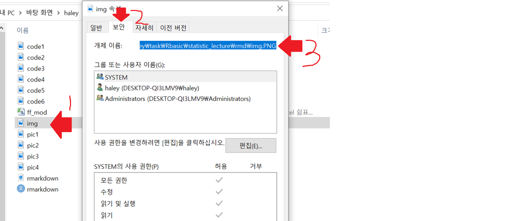

##### 그래프 출력

- 일반적으로 ggplot 이용

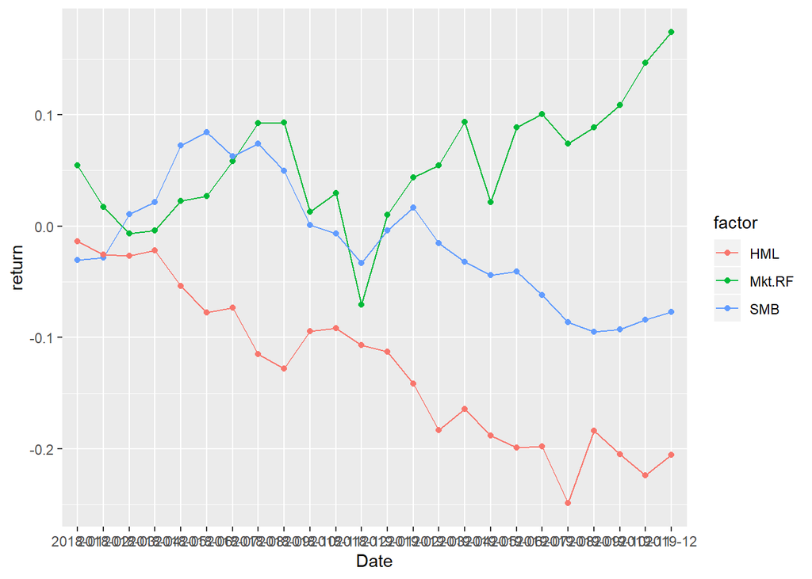

```r
library(ggplot2)
ff_select %>%
  select(Date, 2:4) %>%
  mutate_if(is.numeric, list(~log(1+.) %>% cumsum() )) %>%
  pivot_longer(cols = -Date, names_to = 'factor',
               values_to = 'return') %>%
  ggplot(aes(x = Date, y = return, group = factor)) +
  geom_line(aes(color = factor)) +
  geom_point(aes(color = factor))
```

- highcharter 등의 패키지를 이용해 인터랙티브 그래프도 표현 가능
- https://www.highcharts.com/blog/data-science/highcharts-for-r-users/
- http://jkunst.com/highcharter/
- javascript를 기반으로 하므로, 이를 적용하여 원하는 형태로 변경 가능
  - https://api.highcharts.com/highcharts/

```r
library(highcharter)
ff_select %>%
  select(Date, 2:4) %>%
  mutate_if(is.numeric, list(~log(1+.) %>% cumsum() )) %>%
  pivot_longer(cols = -Date, names_to = 'factor',
               values_to = 'return') %>%
  hchart(.,
         type = "line",
         hcaes(x = Date,
               y = return,
               group = factor)) %>%
  hc_yAxis(title = '',
           opposite = TRUE,
           labels = list(format = "{value}")) %>%
  hc_xAxis(title = '') %>%
  hc_tooltip(pointFormat = '{point.y: .4f}')
```

[interactive chart not shown]

##### 각주 삽입

- 각주를 삽입하고 싶은 단어의 뒤에 `^[내용]`을 입력하면, 페이지 최하단에 각주가 생성됨
- 예: 각주를 삽입하고 싶을 시, `이곳^[원하는 내용을 입력하세요]`에 원하는 단어를 쓰시면 됩니다.

각주를 삽입하고 싶을 시, `이곳1`에 원하는 단어를 쓰시면 됩니다.

##### Reference 추가

- 참고문헌(Reference) 추가는 bib 파일 이용
- 먼저 https://scholar.google.com/ 에서 원하는 논문을 찾아 BibTeX 복사

[figure not shown]

- 복사한 내용을 article.bib 파일에 저장

@article{fama1993common, title={Common risk factors in the returns on stocks and bonds}, author={Fama, Eugene F and French, Kenneth R}, journal={Journal of financial economics}, volume={33}, number={1}, pages={3–56}, year={1993}, publisher={Elsevier} }

- YAML 헤더에 다음 내용을 추가
  - bibliography: [article.bib]
  - 여러개의 bib 파일 사용할 경우 bibliography: [a.bib, b.bib] 형태로 추가
- 참고 문헌임을 밝히고 싶은 위치에 다음과 같이 입력
  - `@` 뒷부분에 bib에서 저장한 article 이름(fama1993common)을 입력

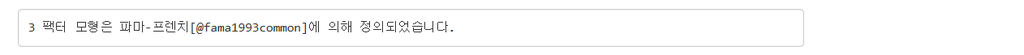

- 이를 출력하면 다음과 같이 나타남

  3 팩터 모형은 파마-프렌치(Fama and French 1993)에 의해 정의되었습니다.
- Reference 페이지 생성을 위해 파일 가장 하단에 다음과 같이 입력
  - `# Reference{-}`
  - `{-}`는 number section을 생성하지 않는 다는 의미
  - 페이지의 가장 마지막에 Reference 페이지가 나타나며, bib에 저장된 모든 문헌이 나타나게 됨